# Part II - prosperLoanData Slide Deck

by Aruma Vivian C

# Investigation Overview

In the investigation ofprosperLoan data, my main variable of interest is Borrower's APR. I want to undesrstand what affects APR for a particular loan and its distribution in the dataset. I examined the relationship between APR and some other variables such as APR vs. loanOriginalAmount and APR vs. rating, as well as Term effect. I explored the following categorical variables 'Occupation, 'LoanStatus', 'EmploymentStatus', 'Term', and 'ProsperRating (Alpha)'. The numeric variables that I explored are: 'BorrowerAPR', 'LoanOriginalAmount', and 'DebtToIncomeRatio'.

# Dataset Overview

prosperLoanData dataset is a csv file, it contains 113,937 rows(loans) with 81 variables on each row. The features(variables) includes amongst others Term, LoanOriginalAmount, Borrower's APR, loan status, 'ProsperRating (Alpha)', DebtToIncomeRatio, The dataset is provided by Udacity.

# What is the Distribution of Borrower's APR?

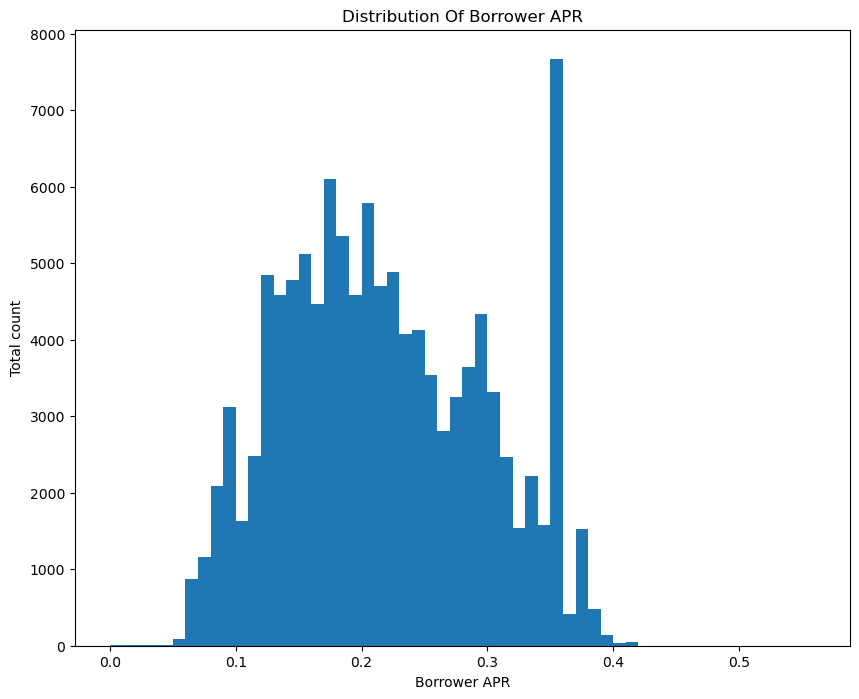

# 2. Check for the relationship between Borrower's APR and Loan original amount

The scatter plot indicate a negative correlation between Borrower's APR and Loan Original amount. This implies an decrease in Borrower's APr(Interest rate) as loan amount increases

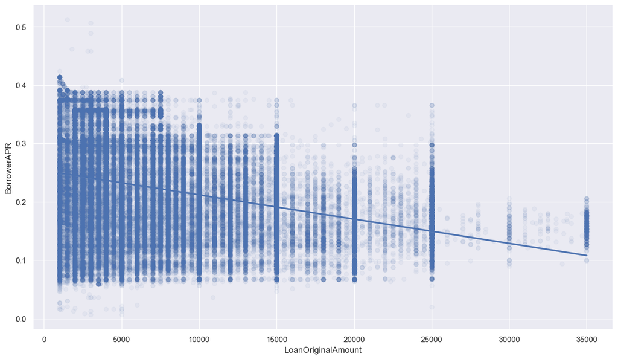

# 3. The relationship between LoanStatus variable and other categorical variables

From the employment vs loan status, it is observed that majority of those employed have an ongoing(current) loan status and most people that are fulltime workers have completed the loan repayment. Majority of people on 36 and 60 months loan duration have their loan status as current whereas those on 12 months duration have their loan completed. The number of current loaners are more in all the scale of rating

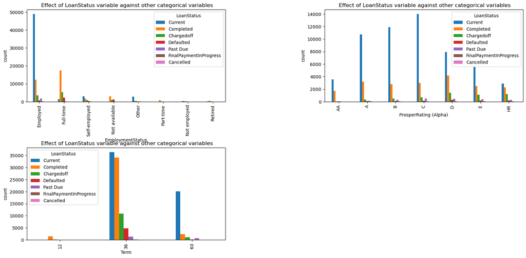

[output not shown]